# writeup

pherreraariza

2/9/2017

### Background

Using devices such as Jawbone Up, Nike FuelBand, and Fitbit it is now possible to collect a large amount of data about personal activity relatively inexpensively. These type of devices are part of the quantified self movement – a group of enthusiasts who take measurements about themselves regularly to improve their health, to find patterns in their behavior, or because they are tech geeks. One thing that people regularly do is quantify how much of a particular activity they do, but they rarely quantify how well they do it. In this project, your goal will be to use data from accelerometers on the belt, forearm, arm, and dumbell of 6 participants. They were asked to perform barbell lifts correctly and incorrectly in 5 different ways. More information is available from the website here: http://web.archive.org/web/20161224072740/http:/groupware.les.inf.puc-rio.br/har (see the section on the Weight Lifting Exercise Dataset).

## Loading the dataset

Prior to load the dataset (divided in training and test datasets), we will need the packages:

```r
setwd("//Users/pherreraariza/Documents/Coursera/8_Machine_Learning/8ML_Project")
library(knitr)
library(caret)
```

```r
library(rpart)
library(rpart.plot)
library(rattle)
library(randomForest)
library(corrplot)
library(nnet)
```

Then, we will load the datasets, and using caret package, we will perform the data partition into a training and a test set, as follows:

```r
# set the URL for the download
UrlTrain <- "http://d396qusza40orc.cloudfront.net/predmachlearn/pml-training.csv"
UrlTest  <- "http://d396qusza40orc.cloudfront.net/predmachlearn/pml-testing.csv"

# download the datasets
training <- read.csv(url(UrlTrain))
testing  <- read.csv(url(UrlTest))

# create a partition with the training dataset
inTrain  <- createDataPartition(training$classe, p=0.7, list=FALSE)
TrainSet <- training[inTrain, ]
TestSet  <- training[-inTrain, ]
```

As we observe that there are a lot of NA values, we need to clean the data, removing the near zero variables (from caret package), the variables with at least 95% of NAs and the identifiers variables (such as id and some timestamps) that will not be used in the models.

```r
# delete near zero variables
NZV <- nearZeroVar(TrainSet)
TrainSet <- TrainSet[, -NZV]
TestSet  <- TestSet[, -NZV]

# remove variables that are mostly NA
mostlyNA    <- sapply(TrainSet, function(x) mean(is.na(x))) > 0.95
TrainSet <- TrainSet[, mostlyNA==FALSE]
TestSet  <- TestSet[, mostlyNA==FALSE]

# remove identification only variables (columns 1 to 5)
TrainSet <- TrainSet[, -(1:5)]
TestSet  <- TestSet[, -(1:5)]
```

In the end, we will have a dataset with 54 variables.

## Correlation variables

We will perform a analysis with a correlation matrix, to see which variables are highly or poorly correlated:

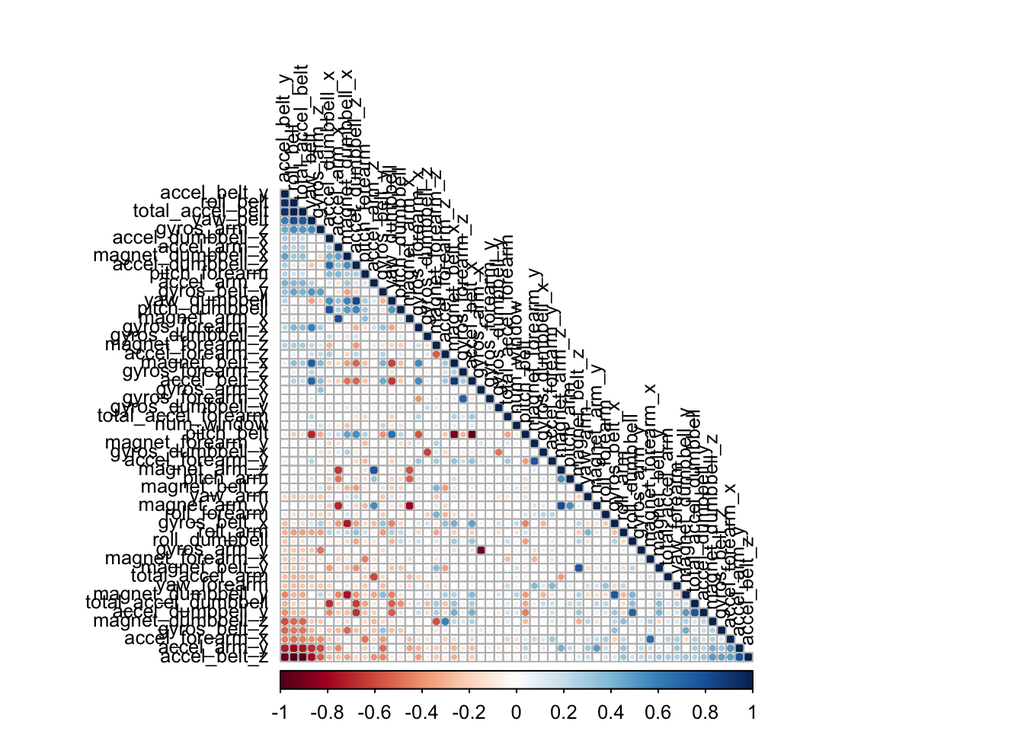

## Random forest

```r
# model fit RF
controlRF <- trainControl(method="cv", number=3, verboseIter=FALSE)
modFitRandForest <- train(classe ~ ., data=TrainSet, method="rf", trControl=controlRF)
modFitRandForest$finalModel
```

```
##
## Call:
##  randomForest(x = x, y = y, mtry = param$mtry)
##                Type of random forest: classification
##                      Number of trees: 500
## No. of variables tried at each split: 27
##
##         OOB estimate of  error rate: 0.2%
## Confusion matrix:
##      A    B    C    D    E  class.error
## A 3905    1    0    0    0 0.0002560164
## B    5 2649    4    0    0 0.0033860045
## C    0    4 2392    0    0 0.0016694491
## D    0    0    8 2244    0 0.0035523979
## E    0    0    0    6 2519 0.0023762376
```

```r
# prediction on Test dataset
predictRandForest <- predict(modFitRandForest, newdata=TestSet)
confMatRandForest <- confusionMatrix(predictRandForest, TestSet$classe)
confMatRandForest
```

```
## Confusion Matrix and Statistics
##
##           Reference
## Prediction    A    B    C    D    E
##          A 1672    2    0    0    0
##          B    1 1134    1    0    0
##          C    0    3 1025    6    0
##          D    0    0    0  958    5
##          E    1    0    0    0 1077
##
## Overall Statistics
##
##                Accuracy : 0.9968
##                  95% CI : (0.995, 0.9981)
##     No Information Rate : 0.2845
##     P-Value [Acc > NIR] : < 2.2e-16
##
##                   Kappa : 0.9959
##  Mcnemar's Test P-Value : NA
##
## Statistics by Class:
##
##                      Class: A Class: B Class: C Class: D Class: E
## Sensitivity            0.9988   0.9956   0.9990   0.9938   0.9954
## Specificity            0.9995   0.9996   0.9981   0.9990   0.9998
## Pos Pred Value         0.9988   0.9982   0.9913   0.9948   0.9991
## Neg Pred Value         0.9995   0.9989   0.9998   0.9988   0.9990
## Prevalence             0.2845   0.1935   0.1743   0.1638   0.1839
## Detection Rate         0.2841   0.1927   0.1742   0.1628   0.1830
## Detection Prevalence   0.2845   0.1930   0.1757   0.1636   0.1832
## Balanced Accuracy      0.9992   0.9976   0.9986   0.9964   0.9976
```

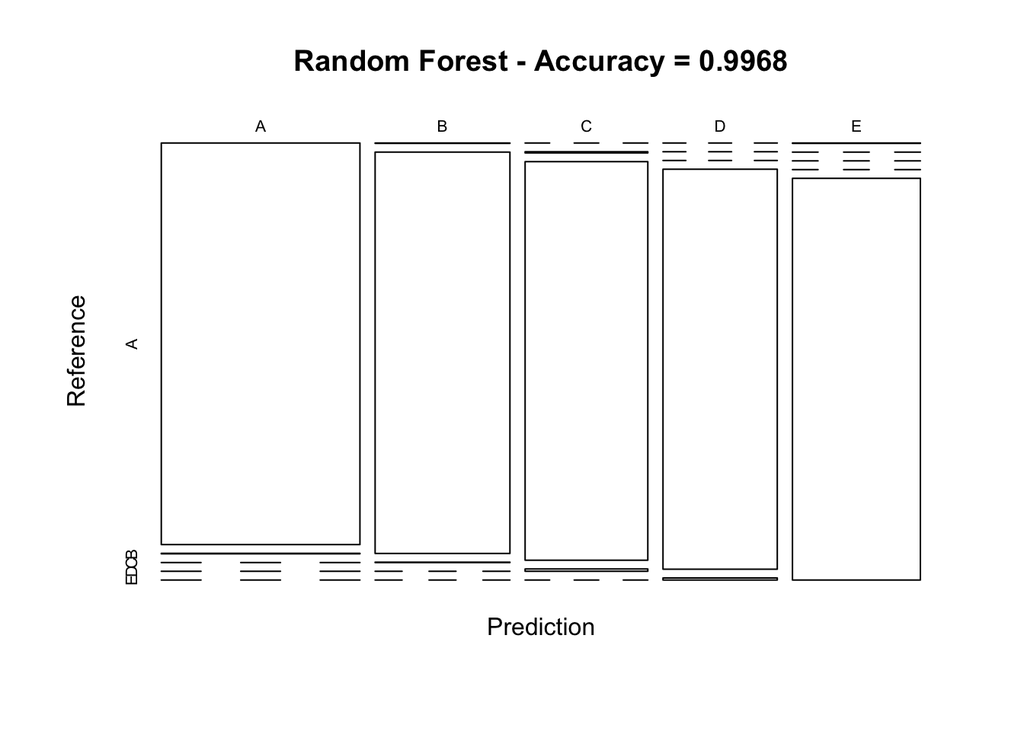

```r
# plot matrix results
plot(confMatRandForest$table, col = confMatRandForest$byClass,
     main = paste("Random Forest - Accuracy =",
                  round(confMatRandForest$overall['Accuracy'], 4)))
```

## Decision tree

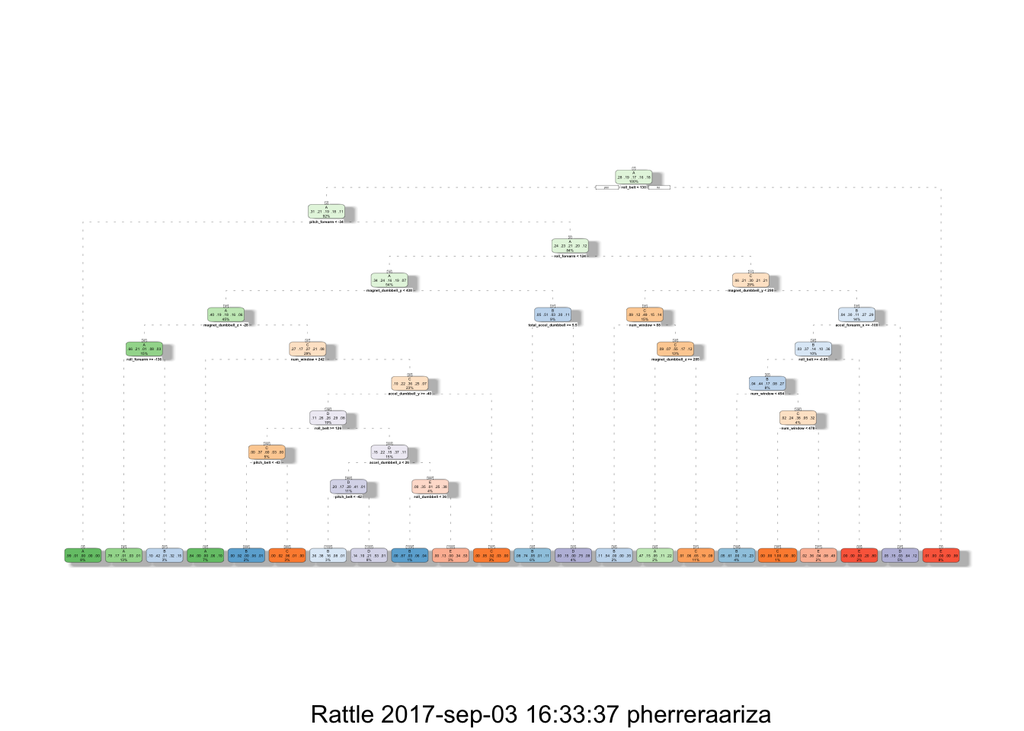

```r
modFitDecTree <- rpart(classe ~ ., data=TrainSet, method="class")
fancyRpartPlot(modFitDecTree)
```

```r
# prediction on Test dataset
predictDecTree <- predict(modFitDecTree, newdata=TestSet, type="class")
confMatDecTree <- confusionMatrix(predictDecTree, TestSet$classe)
confMatDecTree
```

```
## Confusion Matrix and Statistics
##
##           Reference
## Prediction    A    B    C    D    E
##          A 1413  153   16   50   68
##          B  138  718   54  117  175
##          C    9   78  852  123   67
##          D  105  124   99  586   67
##          E    9   66    5   88  705
##
## Overall Statistics
##
##                Accuracy : 0.7263
##                  95% CI : (0.7147, 0.7376)
##     No Information Rate : 0.2845
##     P-Value [Acc > NIR] : < 2.2e-16
##
##                   Kappa : 0.6536
##  Mcnemar's Test P-Value : < 2.2e-16
##
## Statistics by Class:
##
##                      Class: A Class: B Class: C Class: D Class: E
## Sensitivity            0.8441   0.6304   0.8304  0.60788   0.6516
## Specificity            0.9318   0.8980   0.9430  0.91973   0.9650
## Pos Pred Value         0.8312   0.5973   0.7547  0.59735   0.8076
## Neg Pred Value         0.9376   0.9101   0.9634  0.92292   0.9248
## Prevalence             0.2845   0.1935   0.1743  0.16381   0.1839
## Detection Rate         0.2401   0.1220   0.1448  0.09958   0.1198
## Detection Prevalence   0.2889   0.2042   0.1918  0.16669   0.1483
## Balanced Accuracy      0.8880   0.7642   0.8867  0.76381   0.8083
```

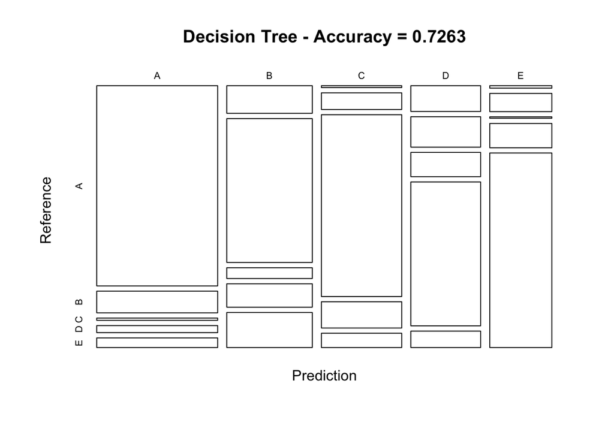

```r
# plot matrix results
plot(confMatDecTree$table, col = confMatDecTree$byClass,
     main = paste("Decision Tree - Accuracy =",
                  round(confMatDecTree$overall['Accuracy'], 4)))
```

## Generalized Boosted Model

```r
# model fit GBM
controlGBM <- trainControl(method = "repeatedcv", number = 5, repeats = 1)
modFitGBM  <- train(classe ~ ., data=TrainSet, method = "gbm",
                    trControl = controlGBM, verbose = FALSE)
modFitGBM$finalModel
```

```
## A gradient boosted model with multinomial loss function.
## 150 iterations were performed.
## There were 53 predictors of which 43 had non-zero influence.
```

```r
# prediction on Test dataset
predictGBM <- predict(modFitGBM, newdata=TestSet)
confMatGBM <- confusionMatrix(predictGBM, TestSet$classe)
confMatGBM
```

```
## Confusion Matrix and Statistics
##
##           Reference
## Prediction    A    B    C    D    E
##          A 1666    7    0    2    0
##          B    6 1108    7    5    1
##          C    0   23 1017   10    0
##          D    0    1    2  946   13
##          E    2    0    0    1 1068
##
## Overall Statistics
##
##                Accuracy : 0.9864
##                  95% CI : (0.9831, 0.9892)
##     No Information Rate : 0.2845
##     P-Value [Acc > NIR] : < 2.2e-16
##
##                   Kappa : 0.9828
##  Mcnemar's Test P-Value : NA
##
## Statistics by Class:
##
##                      Class: A Class: B Class: C Class: D Class: E
## Sensitivity            0.9952   0.9728   0.9912   0.9813   0.9871
## Specificity            0.9979   0.9960   0.9932   0.9967   0.9994
## Pos Pred Value         0.9946   0.9831   0.9686   0.9834   0.9972
## Neg Pred Value         0.9981   0.9935   0.9981   0.9963   0.9971
## Prevalence             0.2845   0.1935   0.1743   0.1638   0.1839
## Detection Rate         0.2831   0.1883   0.1728   0.1607   0.1815
## Detection Prevalence   0.2846   0.1915   0.1784   0.1635   0.1820
## Balanced Accuracy      0.9965   0.9844   0.9922   0.9890   0.9932
```

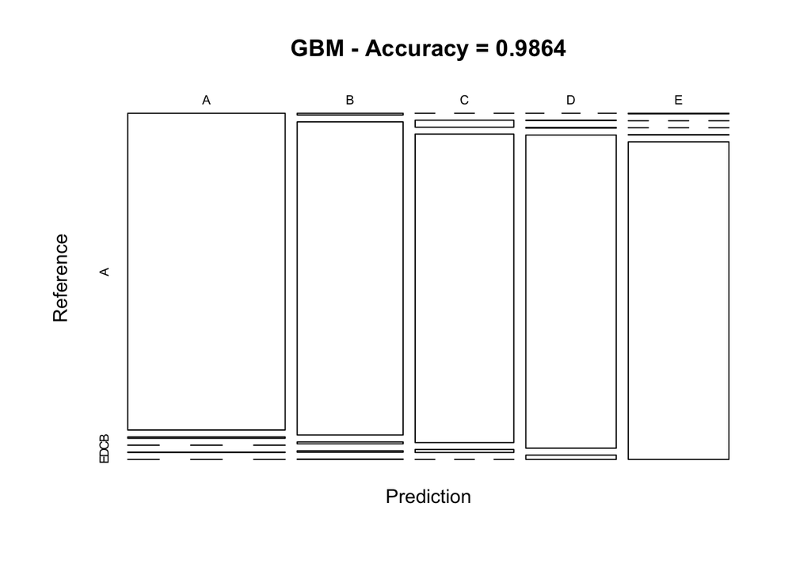

```r
# plot matrix results
plot(confMatGBM$table, col = confMatGBM$byClass,
     main = paste("GBM - Accuracy =", round(confMatGBM$overall['Accuracy'], 4)))
```

## Neural Network

```r
# model fit NN
controlNN <- trainControl(method = "repeatedcv", number = 5, repeats = 1)
modFitNN  <- train(classe ~ ., data=TrainSet, method = "pcaNNet",
                    trControl = controlNN, trace=F)
modFitNN$finalModel
```

```
## Neural Network Model with PCA Pre-Processing
##
## Created from 13737 samples and 53 variables
## PCA needed 38 components to capture 99 percent of the variance
##
## a 38-5-5 network with 225 weights
## options were - decay=0.1
```

```r
# prediction on Test dataset
predictNN <- predict(modFitNN, newdata=TestSet)
confMatNN <- confusionMatrix(predictNN, TestSet$classe)
confMatNN
```

```
## Confusion Matrix and Statistics
##
##           Reference
## Prediction    A    B    C    D    E
##          A 1508  223  144  180   67
##          B   47  610  173  208  174
##          C   29  121  520   84   64
##          D   54  123  173  427   74
##          E   36   62   16   65  703
##
## Overall Statistics
##
##                Accuracy : 0.6403
##                  95% CI : (0.6279, 0.6525)
##     No Information Rate : 0.2845
##     P-Value [Acc > NIR] : < 2.2e-16
##
##                   Kappa : 0.54
##  Mcnemar's Test P-Value : < 2.2e-16
##
## Statistics by Class:
##
##                      Class: A Class: B Class: C Class: D Class: E
## Sensitivity            0.9008   0.5356  0.50682  0.44295   0.6497
## Specificity            0.8542   0.8732  0.93867  0.91384   0.9627
## Pos Pred Value         0.7107   0.5033  0.63570  0.50176   0.7971
## Neg Pred Value         0.9559   0.8868  0.90014  0.89333   0.9242
## Prevalence             0.2845   0.1935  0.17434  0.16381   0.1839
## Detection Rate         0.2562   0.1037  0.08836  0.07256   0.1195
## Detection Prevalence   0.3606   0.2059  0.13900  0.14460   0.1499
## Balanced Accuracy      0.8775   0.7044  0.72275  0.67839   0.8062
```

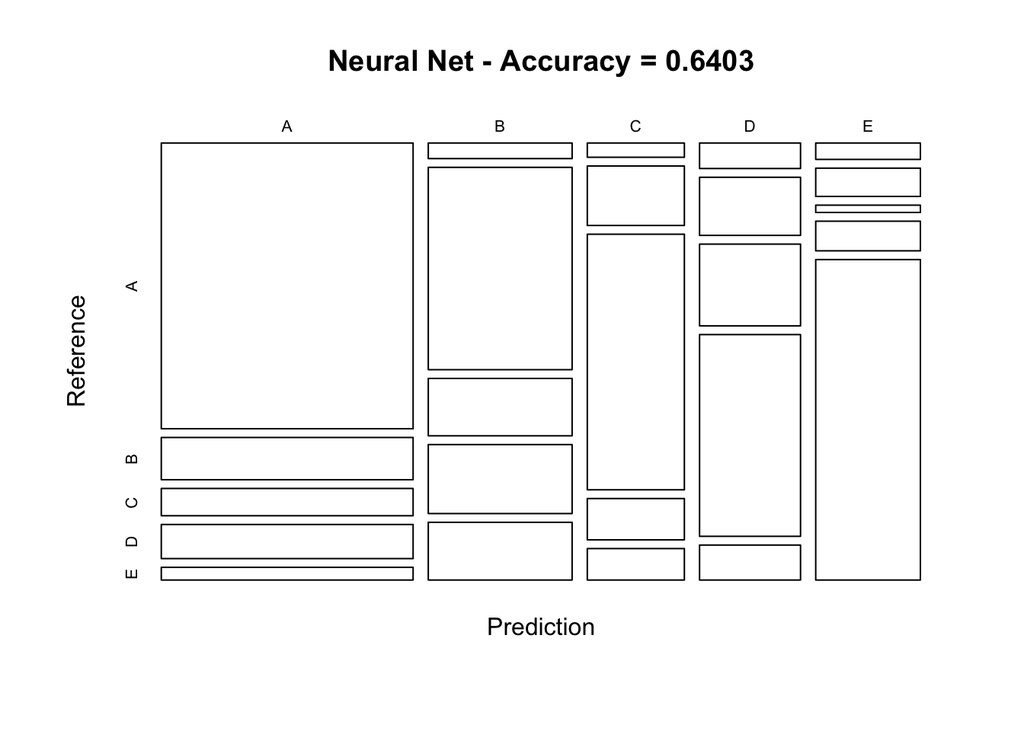

```r
# plot matrix results
plot(confMatNN$table, col = confMatNN$byClass,
     main = paste("Neural Net - Accuracy =", round(confMatNN$overall['Accuracy'], 4)))
```

## Support Vector Machine

```r
# model fit SVM
controlSVM <- trainControl(method = "repeatedcv", number = 5, repeats = 1)
modFitSVM  <- train(classe ~ ., data=TrainSet, method = "svmRadial",
                   trControl = controlSVM, verbose = FALSE)
modFitSVM$finalModel
```

```
## Support Vector Machine object of class "ksvm"
##
## SV type: C-svc  (classification)
##  parameter : cost C = 1
##
## Gaussian Radial Basis kernel function.
##  Hyperparameter : sigma =  0.0123858325169491
##
## Number of Support Vectors : 6715
##
## Objective Function Value : -1013.673 -775.6874 -708.4932 -419.7707 -952.4294 -537.8562 -643.2442 -1033.756 -654.6315 -577.3402
## Training error : 0.056635
```

```r
# prediction on Test dataset
predictSVM <- predict(modFitSVM, newdata=TestSet)
confMatSVM <- confusionMatrix(predictSVM, TestSet$classe)
confMatSVM
```

```
## Confusion Matrix and Statistics
##
##           Reference
## Prediction    A    B    C    D    E
##          A 1646   73    2    1    0
##          B    3 1023   39    4    7
##          C   21   43  968   87   25
##          D    0    0   16  871   35
##          E    4    0    1    1 1015
##
## Overall Statistics
##
##                Accuracy : 0.9385
##                  95% CI : (0.932, 0.9445)
##     No Information Rate : 0.2845
##     P-Value [Acc > NIR] : < 2.2e-16
##
##                   Kappa : 0.9221
##  Mcnemar's Test P-Value : < 2.2e-16
##
## Statistics by Class:
##
##                      Class: A Class: B Class: C Class: D Class: E
## Sensitivity            0.9833   0.8982   0.9435   0.9035   0.9381
## Specificity            0.9820   0.9888   0.9638   0.9896   0.9988
## Pos Pred Value         0.9559   0.9507   0.8462   0.9447   0.9941
## Neg Pred Value         0.9933   0.9759   0.9878   0.9813   0.9862
## Prevalence             0.2845   0.1935   0.1743   0.1638   0.1839
## Detection Rate         0.2797   0.1738   0.1645   0.1480   0.1725
## Detection Prevalence   0.2926   0.1828   0.1944   0.1567   0.1735
## Balanced Accuracy      0.9826   0.9435   0.9536   0.9466   0.9684
```

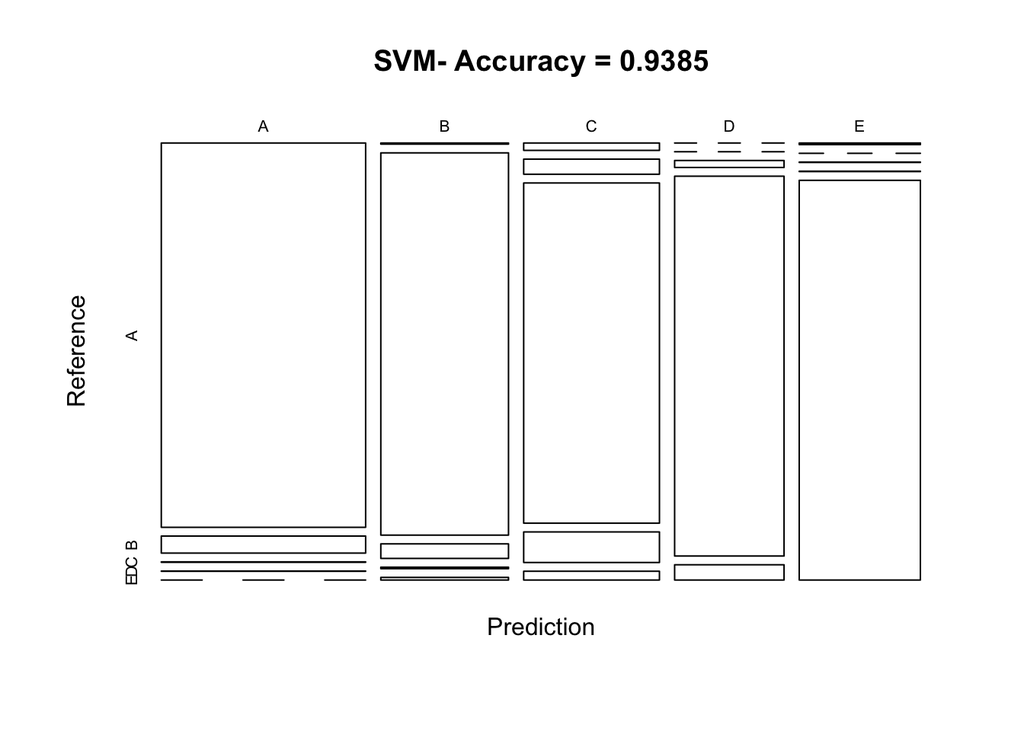

```r
# plot matrix results
plot(confMatSVM$table, col = confMatSVM$byClass,
     main = paste("SVM- Accuracy =", round(confMatSVM$overall['Accuracy'], 4)))
```